# 5 Informed Search

### Informed search strategies

- Informed (**heuristic**) search strategies
  - Use problem-specific knowledge beyond the definition of the problem itself.
  - Can find solutions more efficiently than an uninformed strategy.

**What is a heuristic?**

- **Additional knowledge** of the problem imparted to the search algorithm.
- A heuristic **estimates** how close a state is to a goal.

## 5.1 Best-first search

### Best-first search

- An instance of the general **tree/graph search** algorithm.
- A node is selected for expansion based on an **evaluation function**, $f(n)$, which is construed as a cost estimate.
  - The node with the *lowest* evaluation $f(n)$ is expanded first.
  - The implementation of best-first graph search is identical to that for uniform-cost search, except for the use of *f* instead of *g* to order the priority queue.
  - The choice of $f$ determines the search strategy.
- Most best-first algorithms include as a component of *f* a **heuristic function**, denoted $h(n)$:
  - $h(n)$: estimated cost of the cheapest path from the state at node *n* to a goal state.
- $h(n)$ depends only on the state at node $n$.
- Assumption of $h$:
  - Arbitrary, nonnegative, problem-specific functions.
  - Constraint: if $n$ is a goal node, then $h(n)=0$.

## 5.2 Greedy best-first search

### Greedy best-first search

- Attempts to expand the node that is **closest** to the goal, on the grounds that this is likely to lead to a solution quickly.
- Thus, it evaluates nodes by using just the heuristic function:
  $$f(n)=h(n)$$

### Illustration: Romania

- Use the **straight-line distance** heuristic, which we will call $h_{SLD}$.

  Table: Values of $h_{SLD}$ – straight-line distances to Bucharest.

[figure not shown]

- The initial state:

[figure not shown]

- After expanding Arad:

[figure not shown]

- After expanding Sibu:

[figure not shown]

- After expanding Fagaras:

[figure not shown]

### Properties

- **Time**: $O(b^{m})$, but a good heuristic can give dramatic improvement.
- **Space**: $O(b^{m})$, keeps all nodes in memory.
- **Complete**: No, can get stuck in loops (e.g., Iasi $\rightarrow$ Neamt $\rightarrow$ Iasi $\rightarrow$ Neamt $\rightarrow$ …).
  - Yes in finite space with repeated-state checking.
- **Optimal**: No.

[figure not shown]

## 5.3 A* search

### A* search

- A* search (pronounced A-star search) is the most widely known form of best-first search.
- Ideas:
  - Use heuristic to guide search, but not exclusively.
  - Avoid expanding paths that are already expensive.
- Evaluation function:
  $$f(n)=g(n)+h(n)$$
  - $g(n)$: cost so far to reach $n$.
  - $h(n)$: estimated cost of the cheapest path to goal from $n$.
  - $f(n)$: estimated cost of the cheapest solution through $n$.
- The **algorithm** is identical to **Uniform-Cost-Search** except that A* uses $g+h$ instead of $g$.

### Illustration: Romania

[figure not shown]

### Properties

- **Time**: Exponential in [relative error in $h$ $\times$ length of solution].
- **Space**: Keeps all nodes in memory.
- **Complete**: Yes, unless there are infinitely many nodes with $f\leq f(G)$.
- **Optimal**: Yes, cannot expand $f_{i+1}$ until $f_{i}$ is finished.
  - A* expands all nodes with $f(n)<C^{*}$.
  - A* expands some nodes with $f(n)=C^{*}$.
  - A* expands no nodes with $f(n)>C^{*}$.

### Admissibility and Consistency

**Definition**

$h(n)$ is an **admissible** heuristic:

- if it *never overestimates* the cost to reach the goal,
- or if for every node $n$, $h(n)\leq h^{*}(n)$ (where $h^{*}(n)$ is the true optimal cost to reach the goal state from $n$).

**Definition**

$h(n)$ is a **consistent** heuristic if, for every node *n* and every successor $n'$ of *n* generated by any action $a$, the estimated cost of reaching the goal from *n* is no greater than the step cost of getting to $n'$ plus the estimated cost of reaching the goal from *n’*:
$$h(n)\leq c(n,a,n')+h(n')$$

[figure not shown]

- A consistent heuristic is also admissible.

### Optimal for A*

- Using **tree search** algorithm to find a path from S to G:

[figure not shown]

**Theorem**

The **tree-search version** of A* is optimal if $h(n)$ is admissible.

**Proof**

Suppose some suboptimal goal $G_{2}$ has been generated and is in the frontier. Let $n$ be an unexpanded node on a shortest path to an optimal goal $G$ (graph separation).

- $f(G)=g(G)$ since $h(G)=0$.
- $f(G_{2})=g(G_{2})$ since $h(G_{2})=0$.
- $g(G_{2})>g(G)$ since $G_{2}$ is suboptimal.
- $f(G)>f(n)$ since $h$ is admissible.
- Since $f(G_{2})>f(n)$, A* will never select $G_{2}$ for expansion.

[figure not shown]

- Using **graph search** algorithm to find a path from S to G:

[figure not shown]

**Theorem**

The **graph-search version** of A* is optimal if $h(n)$ is consistent.

**Proof**

- If $h(n)$ is consistent, then the values of $f(n)$ along any path are nondecreasing. Suppose $n'$ is a successor of $n$; then $g(n')=g(n)+c(n,a,n')$ for some action *a*, and we have:
  $$f(n')=g(n')+h(n')=g(n)+c(n,a,n)+h(n')\geq g(n)+h(n)=f(n)$$
- Whenever A* selects a node $n$ for expansion, the optimal path to that node has been found. Were this not the case, there would have to be another frontier node $n'$ on the optimal path from the start node to $n$; since $f(n')<f(n)$, $n'$ would have been selected first.

### Contours

- The search algorithm expands nodes in order of increasing $f$ value.
- We can draw **contours** in the state space, just like the contours in a topographic map.
  - Gradually adds $f$-contours of nodes; contour $i$ has all nodes with $f<f_{i}$, where $f_{i}<f_{i+1}$.

[figure not shown]

- The bands of uniform-cost search will be “circular” around the start state.
- The bands of A* with more accurate heuristics will stretch toward the goal state and become more narrowly focused around the optimal path.

### The 8-puzzle

- The average solution cost for a randomly generated 8-puzzle instance is about 22 steps.
- The branching factor $b$ is about 3.
- 8-puzzle:
  - $3^{22}\approx 3.1\times 10^{10}$ states (using an exhaustive tree search).
  - $9!/2=181,440$ reachable states (using graph search).
- 15-puzzle: around $10^{13}$ states.
- A typical instance of the 8-puzzle. The optimal solution is 26 steps long.

[figure not shown]

### Admissible heuristics for 8-puzzle

- $h_{1}$ = the number of misplaced tiles. $h_{1}$ is an admissible heuristic because it is clear that any tile that is out of place must be moved at least once.
- $h_{2}$ = the sum of the distances of the tiles from their goal positions. $h_{2}$ is also admissible because any move can only move one tile one step closer to the goal.

[figure not shown]

- $h_{1}=1+1+1+1+1+1+1+1=8$ and $h_{2}=3+1+2+2+2+3+3+2=18$.

### Solve 8 puzzle

- Using $h_{2}$:

[figure not shown]

## 5.4 Memory-bounded heuristic search

### Memory-bound heuristic search

- In practice, A* usually runs out of space long before it runs out of time.
- **Idea**: Try something like DFS, but do not forget everything about the branches we have partially explored.

### Iterative-deepening A* (IDA*)

- The main difference with IDS:
  - Cut-off uses the $f$-value ($g+h$) rather than the depth.
  - At each iteration, the cutoff value is the smallest $f$-value of any node that exceeded the cutoff on the previous iteration.
- Avoids the substantial overhead associated with keeping a sorted queue of nodes.
- Practical for many problems with unit step costs, yet difficult with real valued costs.

### Algorithm

```
function IDA*(problem) returns a solution, or failure

  variables:
    f_limit: the current f-COST limit
    root: a node

    root ← Make-Node(problem.Initial-State)
    f_limit ← root.f

    loop do
      solution, f_limit ← DFS-Contour(problem, root, f_limit)
      if solution is non-null then return solution
      if f_limit = ∞ then return failure
```

```
function DFS-Contour(problem, node, f_limit) returns a solution, or failure, a new f-cost limit

  if node.f > f_limit then return null, node.f
  if problem.Goal-Test(node.State) then return Solution(node)
  successors ← ⌀
  for each action in problem.Actions(node.State) do
    add Child-Node(problem, node, action) into successors
  f_next ← ∞
  for each s in successors do
    solution, f_new ← DFS-Contour(problem, s, f_limit)
    if solution is non-null then return solution, f_limit
    f_next ← Min(f_next, f_new)
  return null, f_next
```

### Illustration

- IDA* search for the shortest route from $v_{0}$ (start node) to $v_{25}$ (goal node); each node has a $f$ value.

[figure not shown]

### Recursive best-first search (RBFS)

- Keeps track of the $f$-value of the best alternative path available from any ancestor of the current node.
  - Backtracks when the current node exceeds $f\_limit$.
- As it backtracks, it replaces the $f$-value of each node along the path with the best value $f(n)$ of its children.

### Algorithm

```
function Recursive-Best-First-Search(problem) returns a solution, or failure

  return Rbfs(problem, Make-Node(problem.Initial-State), ∞)

function Rbfs(problem, node, f_limit) returns a solution, or failure and a new f-cost limit

  if problem.Goal-Test(node.State) then return Solution(node)
  successors ← ⌀
  for each action in problem.Actions(node.State) do
    add Child-Node(problem, node, action) into successors
  if successors is empty then return failure, ∞
  for each s in successors do
    // update f with value from previous search, if any
    s.f ← Max(s.g + s.h, node.f)
  loop do
    best ← lowest f-value node in successors
    if best.f > f_limit then return failure, best.f
    alternative ← the second-lowest f-value among successors
    result, best.f ← Rbfs(problem, best, Min(f_limit, alternative))
    if result != failure then return result
```

### Illustration

- Stages in an RBFS search for the shortest route to Bucharest. The $f$-limit value for each recursive call is shown on top of each current node, and every node is labeled with its *f*-cost.

[figure not shown]

1. The path via Rimnicu Vilcea is followed until the current best leaf (Pitesti) has a value that is worse than the best alternative path (Fagaras).

[figure not shown]

2. The recursion unwinds and the best leaf value of the forgotten subtree (417) is backed up to Rimnicu Vilcea; then Fagaras is expanded, revealing a best leaf value of 450.

[figure not shown]

3. The recursion unwinds and the best leaf value of the forgotten subtree (450) is backed up to Fagaras; then Rimnicu Vilcea is expanded. This time, because the best alternative path (through Timisoara) costs at least 447, the expansion continues to Bucharest.

[figure not shown]

### Properties

- **Optimality**:
  - Like A*, optimal if $h(n)$ is admissible.
- **Time complexity**:
  - Difficult to characterize.
  - Depends on accuracy of $h(n)$ and how often the best path changes.
  - Can end up “switching” back and forth.
- **Space complexity**:
  - Linear space: $O(bd)$.
  - Other extreme to A* - uses too little memory even if more memory were available.

### Simplified Memory-bound A* – SMA*

- Similar to A*, but **deletes the worst node** (largest $f$-value) when memory is full.
- SMA* expands the (**newest**) best leaf and deletes the (**oldest**) worst leaf.
- SMA* also backs up the value of the forgotten node to its parent.
  - If there is a tie (equal $f$-values), delete the oldest nodes first.
- Simplified-MA* finds the **optimal reachable solution** given the memory constraint.
  - The depth of the shallowest goal node is less than the memory size (expressed in nodes).
- Time can still be exponential.

### Algorithm

```
function SMA*(problem) returns solution or failure

    node ← Make-Node(problem.Initial-State)
    node.f ← node.g + node.h
    frontier ← priority queue ordered by lowest f

    Insert(node, frontier)

    loop
        if frontier is empty then return failure

        node ← Pop(frontier)

        if Goal-Test(node.State) then return Solution(node)

        if node is not fully expanded then
            s ← Next-Successor(node)
            s.f ← max(s.g + s.h, node.f)
            Insert(s, frontier)
        else
            node.f ← min(child.f for each child of node)
            if node is not root then
                Insert(node.parent, frontier)

        if memory is full then
            worst ← Shallowest-Highest-f leaf in frontier
            Remove(worst, frontier)
            parent ← worst.parent
            Remove worst from parent.children
            parent.f ← min(child.f for each child)
            Insert(parent, frontier)
```

### Illustration

- Find the lowest-cost goal node with enough memory:
  - Max Nodes = 3.
  - A: start node and D, F, I, J: goal nodes.
  - Each edge/node is labelled with its step cost/heuristic value.

[figure not shown]

- Consider only current f-cost:

[figure not shown]

### Learning to search better

- Could an agent learn how to search better? Yes.
- **Metalevel state space**: Each state captures the internal (computational) state of a program that is searching in an **object-level state space**.
- A **metalevel learning algorithm** learns from these experiences to avoid exploring unpromising subtrees.
- For example, the map of Romania problem:
  - The internal state of the A* algorithm is the current search tree.
  - Each action in the metalevel state space is a computation step that alters the internal state; for example, each computation step in A* expands a leaf node and adds its successors to the tree.

## 5.5 Heuristic functions

### The effect of heuristic accuracy on performance

- **Effective branching factor** $b^{*}$ characterizes the quality of a heuristic.
- If the total number of nodes generated by A* for a particular problem is $N$ and the solution depth is $d$, then $b^{*}$ is the branching factor that a uniform tree of depth *d* would have to have in order to contain $N+1$ nodes:
  $$N+1=1+\left(b^{*}\right)+\left(b^{*}\right)^{2}+...+\left(b^{*}\right)^{d}$$
- $b^{*}$ varies across problem instances, but is fairly constant for sufficiently hard problems.
- A well-designed heuristic would have a value of $b^{*}$ close to 1 $\Rightarrow$ fairly large problems solved at reasonable cost.

Comparison of the search costs and effective branching factors for the IDS and A* algorithms with $h_{1}$, $h_{2}$. Data are averaged over 100 instances of the 8-puzzle for each of various solution lengths *d*.

| d | IDS | A*($h_{1}$) | A*($h_{2}$) | IDS | A*($h_{1}$) | A*($h_{2}$) |
| --- | --- | --- | --- | --- | --- | --- |
| 2 | 10 | 6 | 6 | 2.45 | 1.79 | 1.79 |
| 4 | 112 | 13 | 12 | 2.87 | 1.48 | 1.45 |
| 6 | 680 | 20 | 18 | 2.73 | 1.34 | 1.30 |
| 8 | 6384 | 39 | 25 | 2.80 | 1.33 | 1.24 |
| 10 | 47127 | 93 | 39 | 2.79 | 1.38 | 1.22 |
| 12 | 3644035 | 227 | 73 | 2.78 | 1.42 | 1.24 |
| 14 | – | 539 | 113 | – | 1.44 | 1.23 |
| 16 | – | 1301 | 211 | – | 1.45 | 1.25 |
| 18 | – | 3056 | 363 | – | 1.46 | 1.26 |
| 20 | – | 7276 | 676 | – | 1.47 | 1.27 |
| 22 | – | 18094 | 1219 | – | 1.48 | 1.28 |
| 24 | – | 39135 | 1641 | – | 1.48 | 1.26 |

### Dominance and Composite

- If $h_{2}(n)\geq h_{1}(n)$ for all $n$ (both admissible), then $h_{2}$ **dominates** $h_{1}$ and is better for search.
  - A* using $h_{2}$ will never expand more nodes than A* using $h_{1}$.
- Hence, it is generally better to use a heuristic function with **higher values**, provided it is consistent and that the computation time for the heuristic is not too long.
- Suppose a collection of admissible heuristics {$h_{1},...,h_{m}$} is available for a problem and none of them dominates any of the others.
- The **composite heuristic function** is defined as $h(n)=\max\{h_{1}(n),...,h_{m}(n)\}$. It is consistent and dominates all component heuristics.

### Relaxed problems

**Definition**

A problem with fewer restrictions on the actions is called a **relaxed problem**.

- Prove that the angle in a semicircle is a right angle.

[figure not shown]

### Generating admissible heuristics from relaxed problems

- The state-space graph of the relaxed problem is a **supergraph** of the original state space because the removal of restrictions creates added edges in the graph.
- Original problem state-space:

[figure not shown]

- Relaxed problem state-space:

[figure not shown]

- Hence, *the cost of an optimal solution to a relaxed problem is an admissible heuristic for the original problem*.
- Furthermore, because the derived heuristic is an exact cost for the relaxed problem, it must obey the triangle inequality and is therefore **consistent**.

**Original problem of 8 puzzle**

A tile can move from square A to square B if A is horizontally or vertically adjacent to B and B is blank.

We can generate three relaxed problems by removing one or both of the conditions:

**Relaxed problems**

1. A tile can move from square A to square B if A is adjacent to B $\to$ $h_{2}$.
2. A tile can move from square A to square B if B is blank $\to$ exercise.
3. A tile can move from square A to square B $\to$ $h_{1}$.

### Generating admissible heuristics from subproblems

- Admissible heuristics can also be derived from the solution cost of a **subproblem** of a given problem.
  - The cost of the optimal solution of this subproblem $\leq$ the cost of the original problem (lower bound).
  - It can be more accurate than Manhattan distance in some cases.
- A subproblem of the 8-puzzle instance. The task is to get tiles 1, 2, 3, and 4 into their correct positions, without worrying about what happens to the other tiles.

[figure not shown]

### Goal fixed?

- Assume that the goal state G is fixed:

[figure not shown]

- Using to find the shortest path from G to the other states:

[figure not shown]

- The final $g$ values can be considered as optimal $h^{\ast}$ values:

[figure not shown]

### Pattern databases

- **Pattern databases** (PDB) store the exact solution costs for every possible subproblem instance.
  - E.g., every possible configuration of the four tiles and the blank.
- The database itself is constructed by searching back from the goal and recording the cost of each new pattern encountered; the expense of this search is amortized over many subsequent problem instances.
- The complete heuristic is constructed using the patterns in the databases.

### Computing the Heuristic

[figure not shown]

- 31 moves needed to solve red tiles.
- 22 moves need to solve blue tiles.
- Overall heuristic is maximum of $31=\max(31,22)$ moves.

### Disjoint pattern databases

- Limitation of traditional PDB: Taking the max $\to$ diminishing returns on additional PDBs.
- **Disjoint pattern databases**: *Count only moves of the pattern tiles, ignoring non-pattern moves.*
- If no tile belongs to more than one pattern, **add** their heuristic values.

### Computing the Heuristic

[figure not shown]

- 20 moves needed to solve red tiles.
- 25 moves needed to solve blue tiles.
- Overall heuristic is sum, or $45=20+25$ moves.

### Performance

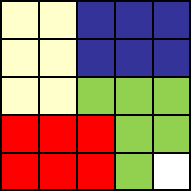

### Learning heuristics from experience

- Experience means solving a lot of instances of a problem.
  - E.g., solving lots of 8-puzzles.
- Each optimal solution to a problem instance provides examples from which $h(n)$ can be learned.
- Learning algorithms:
  - Neural nets
  - Decision trees
  - Inductive learning

## 5.6 References